# Environmental indicator analysis-Tilefish

```r
# Loading packages and data
library(ggplot2)
library(ecodata)
library(lubridate)
library(dplyr)
library(stringr)
library(marmap) # bathymetry
library(RColorBrewer)
library(ggnewscale)
library(sf)
library(cowplot)
library(tidyverse)
library(ggpubr)
library(sf)
library(ggdist)
library(ggpubr)
library(wesanderson)
library(raster)
#library(glmTMB)
library(ggpmisc)
library(mgcViz)
library(gratia)

# Recruitment estimates from 2021 report
recruit <- read.csv(here::here('data/assessment_data/tilefish_rec_estimate_2021.csv'))

# loading in shape files for maps
US.areas <- st_read(here::here('shapefiles/USA.shp'), quiet = TRUE)
canada.areas <- st_read(here::here('shapefiles/Canada.shp'), quiet = TRUE)
bts_strata <- st_read(here::here('shapefiles/NES_BOTTOM_TRAWL_STRATA.shp'),
                      quiet = TRUE)
# plot(bts_strata) # to see all bottom trawl strata

gtf_strata <- bts_strata %>%
  filter(STRATUMA %in% c('01030', '01040', '01070', '01080', '01110', '01120',
                         '01140', '01150', '01670', '01680', '01710', '01720',
                         '01750', '01760')) # select just the gtf strata
# plot(gtf_strata)
bathy <- marmap::getNOAA.bathy(-81,-58, 27, 46)
bathy = fortify.bathy(bathy)
```

### Recruitment estimate

Figure 3. Age-1 recruitment estimate from the 2021 tilefish assessment across all years

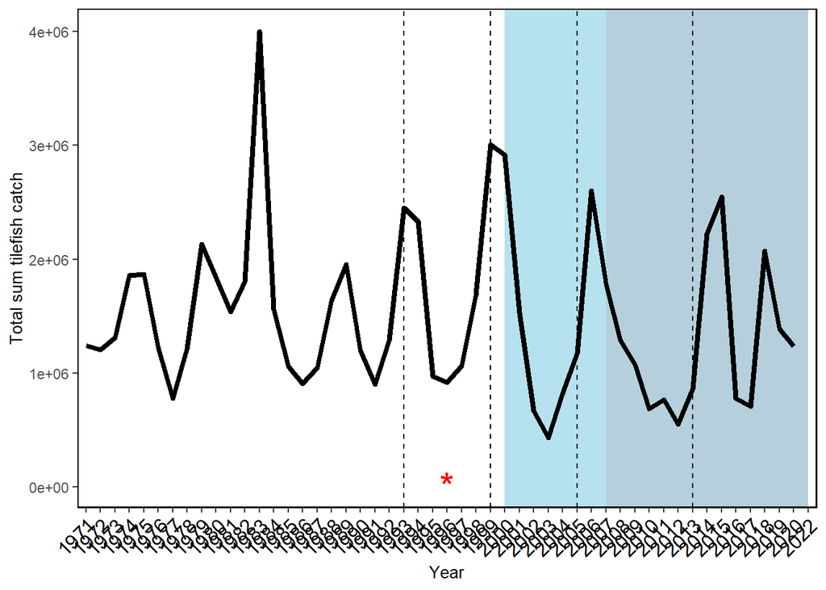

```r
ggplot(recruit, aes(x = factor(year), y = recruit_est, group = 1))+
   geom_rect(aes(xmin = '2007', xmax = '2022', ymin = -Inf, ymax = Inf),
            fill = 'red', alpha = 0.02) +
  geom_rect(aes(xmin = '2000', xmax = '2022', ymin = -Inf, ymax = Inf),
            fill = 'lightblue', alpha = 0.05) +
   geom_vline(xintercept = c('1993','1999', '2005', '2013'), lty = 2) +
  geom_line(color = 'black', size = 1.5) +
  annotate("text", label = "*",
    x = 26, y = 14000, size = 8, colour = "red" )+
  xlab('Year') +
  ylab('Total sum tilefish catch') +
  # facet_wrap(~month)+
  theme(axis.text.x = element_text(color = 'black',
                                   size = 12, angle = 45, vjust = 1, hjust=1)) +
  ecodata::theme_facet()
```

##### SST

```r
# SST
sst<-read.csv(here::here('data/sst/sst_ts_gtf_strata.csv'))
```

```r
# SST with season lag
sst.lag <- sst %>%
  arrange(year, month) %>%
  mutate(
         sst_lag12 = lag(weighted_mean_sst,12))

# Join with recruit estimate
df <- dplyr::full_join(recruit, sst.lag %>%
                   group_by(year) %>%
                   filter(year %in% c(2000:2020)),
dplyr::select(year, month, recruit.est, mean_sst, weighted_mean_sst, sst_lag3, sst_lag6, sst_lag9, sst_lag12),
                 by = join_by(year))
sst.rec <- df[-c(1:29),] #removes year < 2000 (when SST data begins)
```

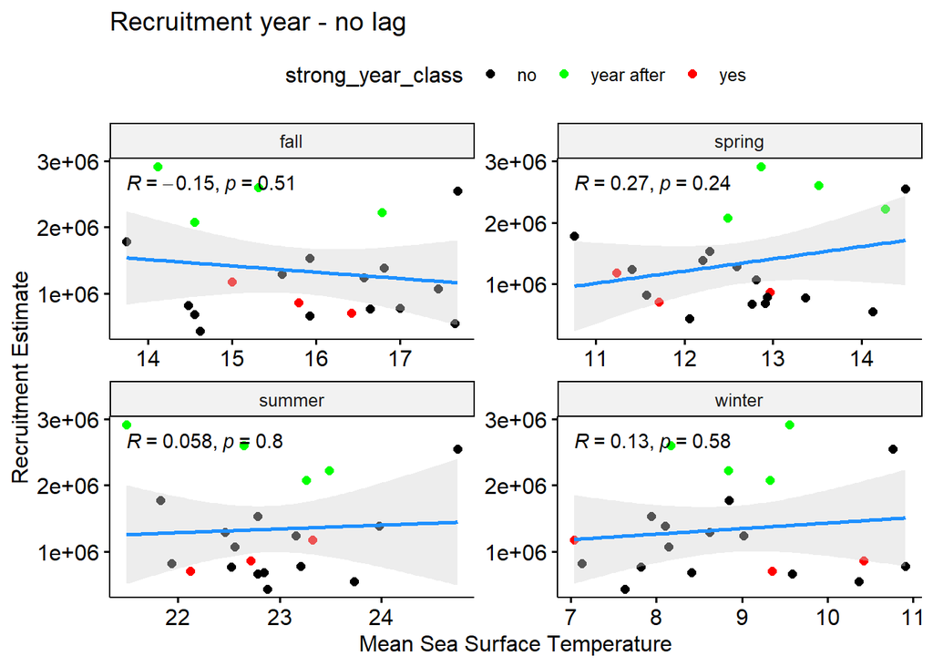

```r
df = sst.rec %>%
  mutate(season = case_when(month %in% c(1,2,3) ~ 'winter',
                            month %in% c(4,5,6) ~ 'spring',
                            month %in% c(7,8,9) ~ 'summer',
                            month %in% c(10,11,12) ~ 'fall'),
         strong_year_class = case_when(year %in% c(2005,2013,2017) ~ 'yes',
                                  year %in% c(2000,2006,2014,2018) ~ 'year after',
                                  year %in% c(2001:2004,2007:2012,2015:2016,2019:2020) ~ 'no'))


df %>% group_by(year, season, strong_year_class) %>%
  summarize(sst = mean(weighted_mean_sst),
            r = mean(recruit_est)) %>%
  ggscatter(x = "sst", y = "r",
            add = "reg.line", conf.int = TRUE,
            color = "strong_year_class", palette = c("black", "green", "red"),
            cor.coef = TRUE, cor.coeff.args = list(method="pearson"),
            add.params=list(color="dodgerblue", fill="lightgray"),
            xlab = "Mean Sea Surface Temperature", ylab = "Recruitment Estimate",
            title="Recruitment year - no lag") +
  facet_wrap(~season, scales = 'free')
```

Here we have SST lagged by 1 year - by season

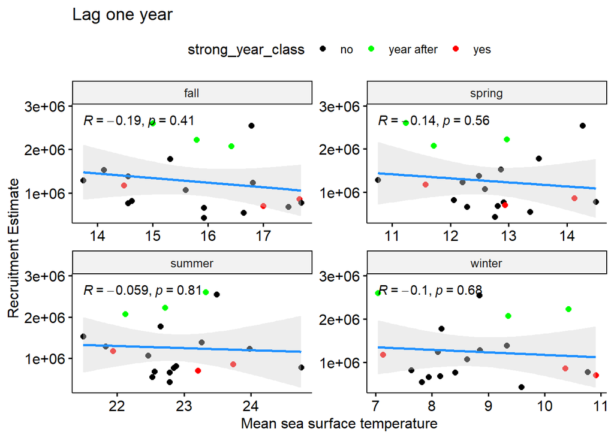

```r
df %>% group_by(year, season, strong_year_class) %>%
  summarize(sst = mean(sst_lag12),
            r = mean(recruit_est)) %>%
  ggscatter(x = "sst", y = "r",
            add = "reg.line", conf.int = TRUE,
            color = "strong_year_class", palette = c("black", "green", "red"),
            cor.coef = TRUE, cor.coeff.args = list(method="pearson"),
            add.params=list(color="dodgerblue", fill="lightgray"),
            xlab = "Mean sea surface temperature", ylab = "Recruitment Estimate",
            title="Lag one year")+
  facet_wrap(~season, scales = 'free')
```

##### Bottom T analysis

The following figures compare in-situ bottom temperature from the study-fleet data set to the recruitment estimate.

- Note here temperatures are averaged across all depths > 50 for each month.

```r
bt <- read.csv(here::here('data/bottom_temp/bt_ts_gtf_1970_2023.csv'))

# BT with year lag
bt.lag <- bt %>%
  filter(year %in% c(1997:2020)) %>%
  mutate(
         bt_lag12 = lag(weighted_mean_bt,12))

# Join with recruit estimate
bt.rec <- dplyr::full_join(recruit, bt.lag, by = join_by(year)) %>%
  dplyr::select(year, month, recruit_est, weighted_mean_bt, bt_lag12) %>%
  tidyr::drop_na()
```

Here is bottom temp and recruitment not lagged

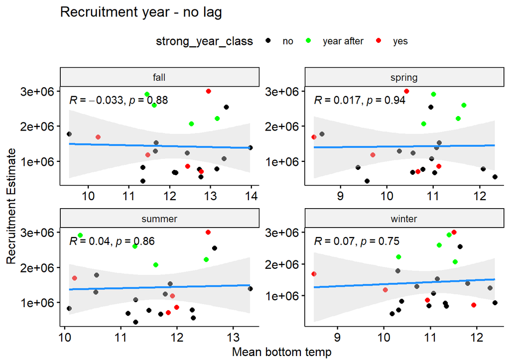

```r
df = bt.rec %>%
  mutate(season = case_when(month %in% c(1,2,3) ~ 'winter',
                            month %in% c(4,5,6) ~ 'spring',
                            month %in% c(7,8,9) ~ 'summer',
                            month %in% c(10,11,12) ~ 'fall'),
         strong_year_class = case_when(year %in% c(1998,1999,2005,2013,2017) ~ 'yes',
                                  year %in% c(2000,2006,2014,2018) ~ 'year after',
                                  year %in% c(2001:2004,2007:2012,2015:2016,2019:2020) ~ 'no'))


df %>% group_by(year, season, strong_year_class) %>%
  summarize(bt = mean(weighted_mean_bt),
            r = mean(recruit_est)) %>%
  ggscatter(x = "bt", y = "r",
            add = "reg.line", conf.int = TRUE,
            color = "strong_year_class", palette = c("black", "green", "red"),
            cor.coef = TRUE, cor.coeff.args = list(method="pearson"),
            add.params=list(color="dodgerblue", fill="lightgray"),
            xlab = "Mean bottom temp", ylab = "Recruitment Estimate",
            title="Recruitment year - no lag")+
  facet_wrap(~season, scales = 'free')
```

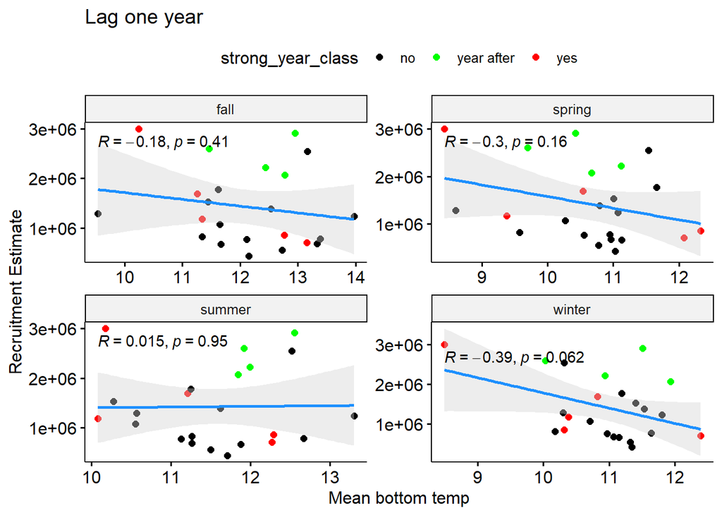

```r
df %>% group_by(year, season, strong_year_class) %>%
  summarize(bt = mean(bt_lag12),
            r = mean(recruit_est)) %>%
  ggscatter(x = "bt", y = "r",
            add = "reg.line", conf.int = TRUE,
            color = "strong_year_class", palette = c("black", "green", "red"),
            cor.coef = TRUE, cor.coeff.args = list(method="pearson"),
            add.params=list(color="dodgerblue", fill="lightgray"),
            xlab = "Mean bottom temp", ylab = "Recruitment Estimate",
            title="Lag one year")+
  facet_wrap(~season, scales = 'free')
```

##### Salinity

Here we explore salinity from the GLORYS reanalysis model at three different depths

- 78 meters (relevant to larvae, recruits)
- 92 meters (relevant recruits, juveniles)
- 110 meters (relevant to juveniles, adults)

##### Salinity analysis

78 Meters

```r
# Read in data at 78 m depth
sal78 <- read.csv(here::here('data/salinity/sal_78m_monthly_ts_gtf.csv'))

# sal78m with year lag
sal78.lag <- sal78 %>%
  filter(year %in% c(1997:2020)) %>%
  mutate(
         sal78_lag12 = lag(weighted_mean_sal_78m,12),
         year = as.numeric(year))


# Join with recruit estimate
sal78.rec <- dplyr::full_join(recruit, sal78.lag, by = join_by(year)) %>%
  dplyr::select(year, month, recruit_est, weighted_mean_sal_78m, sal78_lag12) %>%
  tidyr::drop_na()
```

Salinity 78m

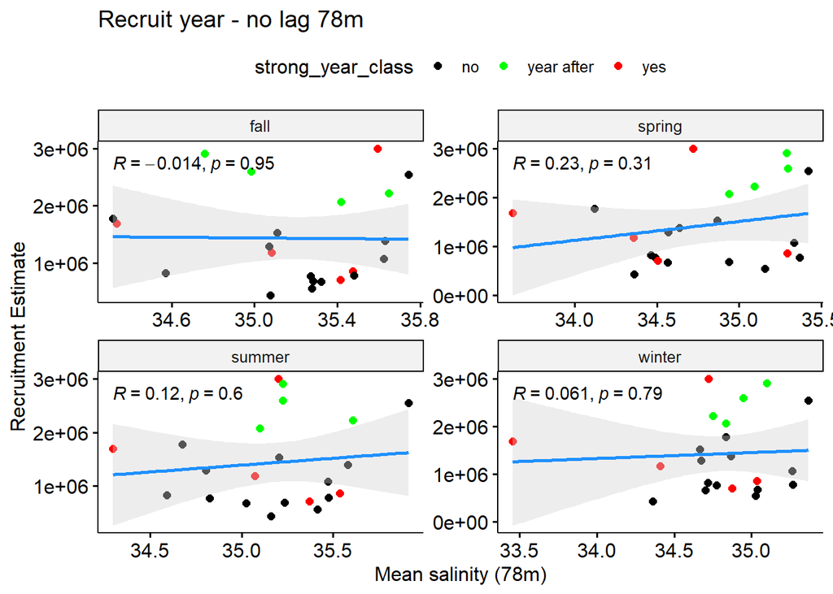

```r
df = sal78.rec %>%
  mutate(season = case_when(month %in% c(1,2,3) ~ 'winter',
                            month %in% c(4,5,6) ~ 'spring',
                            month %in% c(7,8,9) ~ 'summer',
                            month %in% c(10,11,12) ~ 'fall'),
         strong_year_class = case_when(year %in% c(1998,1999,2005,2013,2017) ~ 'yes',
                                  year %in% c(2000,2006,2014,2018) ~ 'year after',
                                  year %in% c(2001:2004,2007:2012,2015:2016,2019:2020) ~ 'no'))

# Plot without lag
df %>% group_by(year, season, strong_year_class) %>%
  summarize(sal78 = mean(weighted_mean_sal_78m),
            r = mean(recruit_est)) %>%
  ggscatter(x = "sal78", y = "r",
            add = "reg.line", conf.int = TRUE,
            color = "strong_year_class", palette = c("black", "green", "red"),
            cor.coef = TRUE, cor.coeff.args = list(method="pearson"),
            add.params=list(color="dodgerblue", fill="lightgray"),
            xlab = "Mean salinity (78m)", ylab = "Recruitment Estimate",
            title="Recruit year - no lag 78m")+
  facet_wrap(~season, scales = 'free')
```

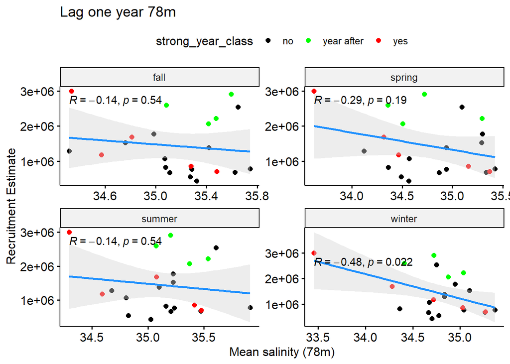

```r
# Plot with lag
df %>% group_by(year, season, strong_year_class) %>%
  summarize(sal78 = mean(sal78_lag12),
            r = mean(recruit_est)) %>%
  ggscatter(x = "sal78", y = "r",
            add = "reg.line", conf.int = TRUE,
            color = "strong_year_class", palette = c("black", "green", "red"),
            cor.coef = TRUE, cor.coeff.args = list(method="pearson"),
            add.params=list(color="dodgerblue", fill="lightgray"),
            xlab = "Mean salinity (78m)", ylab = "Recruitment Estimate",
            title="Lag one year 78m")+
  facet_wrap(~season, scales = 'free')
```

92 Meters

```r
# Read in data at 92 meter depth

sal92 <- read.csv(here::here('data/salinity/sal_92m_monthly_ts_gtf.csv'))

sal92.lag <- sal92 %>%
  filter(year %in% c(1997:2020)) %>%
  mutate(
         sal92_lag12 = lag(weighted_mean_sal_92m,12),
         year = as.numeric(year))


# Join with recruit estimate
sal92.rec <- dplyr::full_join(recruit, sal92.lag, by = join_by(year)) %>%
  dplyr::select(year, month, recruit_est, weighted_mean_sal_92m, sal92_lag12) %>%
  tidyr::drop_na()
```

No lag, 1 year lag plots

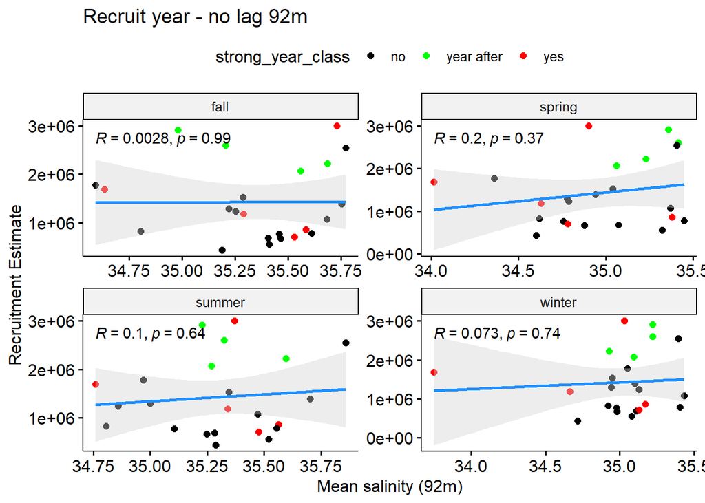

```r
df = sal92.rec %>%
  mutate(season = case_when(month %in% c(1,2,3) ~ 'winter',
                            month %in% c(4,5,6) ~ 'spring',
                            month %in% c(7,8,9) ~ 'summer',
                            month %in% c(10,11,12) ~ 'fall'),
         strong_year_class = case_when(year %in% c(1998,1999,2005,2013,2017) ~ 'yes',
                                  year %in% c(2000,2006,2014,2018) ~ 'year after',
                                  year %in% c(2001:2004,2007:2012,2015:2016,2019:2020) ~ 'no'))

# Plot without lag
df %>% group_by(year, season, strong_year_class) %>%
  summarize(sal92 = mean(weighted_mean_sal_92m),
            r = mean(recruit_est)) %>%
  ggscatter(x = "sal92", y = "r",
            add = "reg.line", conf.int = TRUE,
            color = "strong_year_class", palette = c("black", "green", "red"),
            cor.coef = TRUE, cor.coeff.args = list(method="pearson"),
            add.params=list(color="dodgerblue", fill="lightgray"),
            xlab = "Mean salinity (92m)", ylab = "Recruitment Estimate",
            title="Recruit year - no lag 92m")+
  facet_wrap(~season, scales = 'free')
```

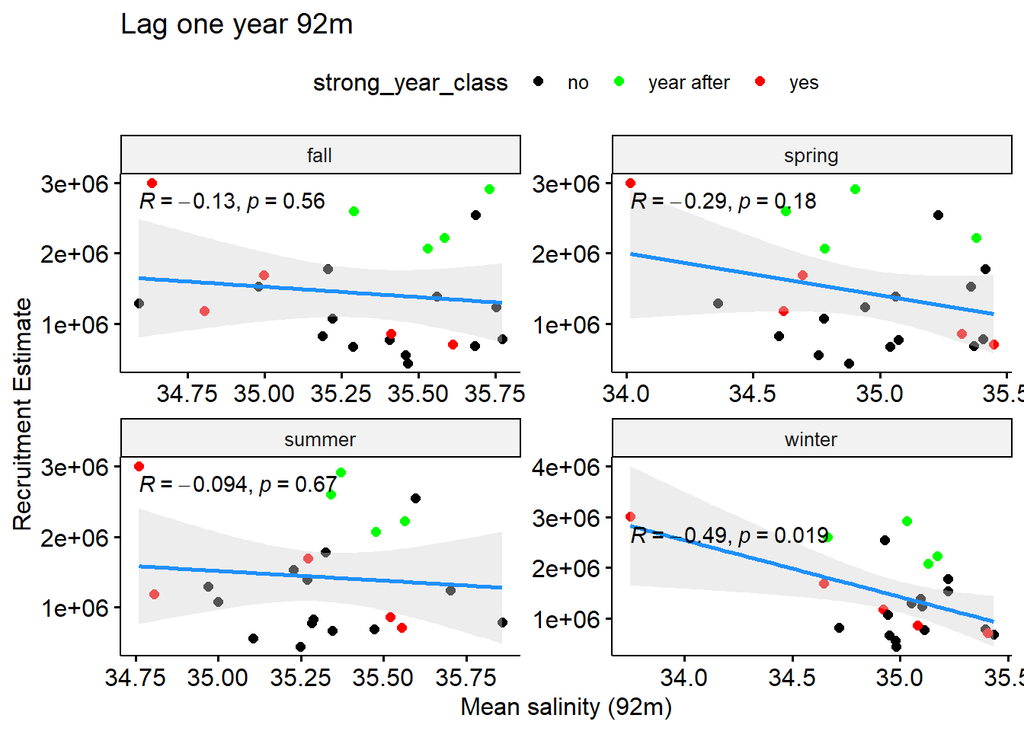

```r
# Plot with lag
df %>% group_by(year, season, strong_year_class) %>%
  summarize(sal92 = mean(sal92_lag12),
            r = mean(recruit_est)) %>%
  ggscatter(x = "sal92", y = "r",
            add = "reg.line", conf.int = TRUE,
            color = "strong_year_class", palette = c("black", "green", "red"),
            cor.coef = TRUE, cor.coeff.args = list(method="pearson"),
            add.params=list(color="dodgerblue", fill="lightgray"),
            xlab = "Mean salinity (92m)", ylab = "Recruitment Estimate",
            title="Lag one year 92m")+
  facet_wrap(~season, scales = 'free')
```

110 Meters

```r
# Wrangling the data
sal110 <- read.csv(here::here('data/salinity/sal_110m_monthly_ts_gtf.csv'))

#sal110 with lags
sal110.lag <- sal110 %>%
  filter(year %in% c(1997:2020)) %>%
  mutate(
         sal110_lag12 = lag(weighted_mean_sal_110m,12),
         year = as.numeric(year))


# Join with recruit estimate
sal110.rec <- dplyr::full_join(recruit, sal110.lag, by = join_by(year)) %>%
  dplyr::select(year, month, recruit_est, weighted_mean_sal_110m,sal110_lag12) %>%
  tidyr::drop_na()
```

No lag, 1 year lag plots

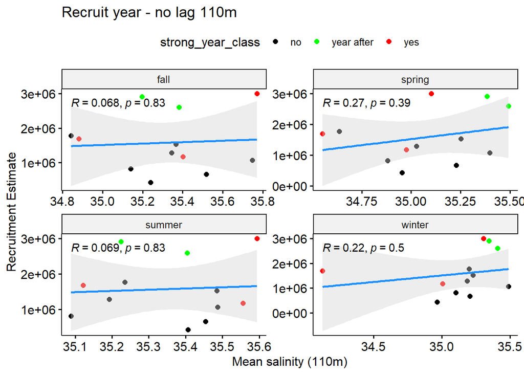

```r
df = sal110.rec %>%
  mutate(season = case_when(month %in% c(1,2,3) ~ 'winter',
                            month %in% c(4,5,6) ~ 'spring',
                            month %in% c(7,8,9) ~ 'summer',
                            month %in% c(10,11,12) ~ 'fall'),
         strong_year_class = case_when(year %in% c(1998,1999,2005,2013,2017) ~ 'yes',
                                  year %in% c(2000,2006,2014,2018) ~ 'year after',
                                  year %in% c(2001:2004,2007:2012,2015:2016,2019:2020) ~ 'no'))

# Plot without lag
df %>% group_by(year, season, strong_year_class) %>%
  summarize(sal110 = mean(weighted_mean_sal_110m),
            r = mean(recruit_est)) %>%
  ggscatter(x = "sal110", y = "r",
            add = "reg.line", conf.int = TRUE,
            color = "strong_year_class", palette = c("black", "green", "red"),
            cor.coef = TRUE, cor.coeff.args = list(method="pearson"),
            add.params=list(color="dodgerblue", fill="lightgray"),
            xlab = "Mean salinity (110m)", ylab = "Recruitment Estimate",
            title="Recruit year - no lag 110m")+
  facet_wrap(~season, scales = 'free')
```

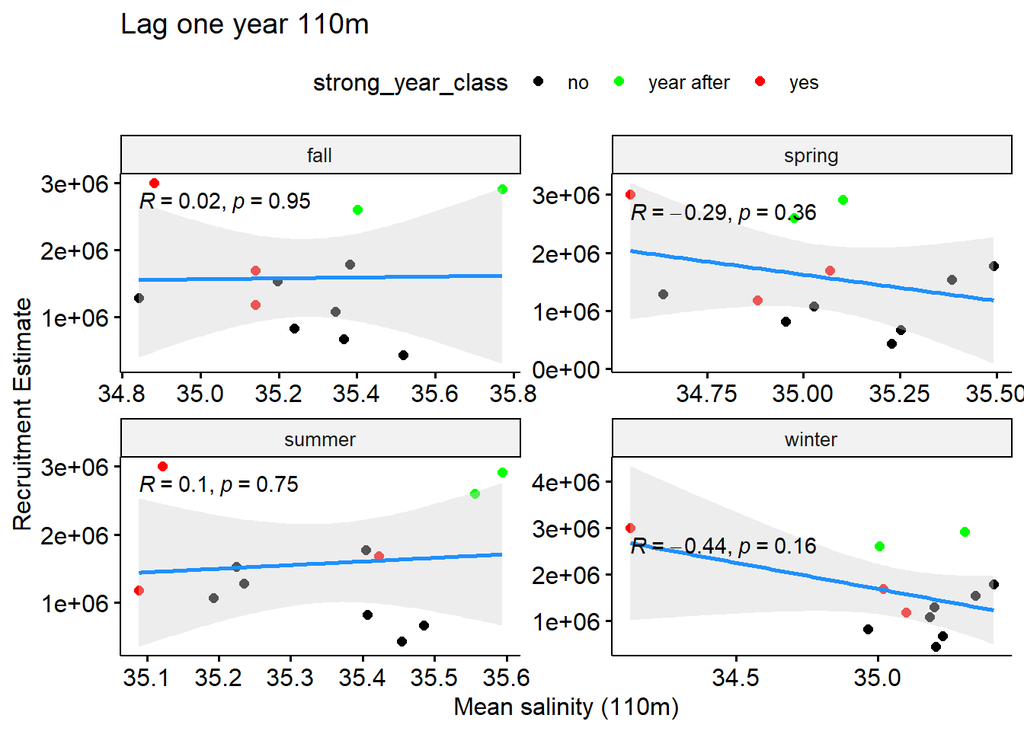

```r
# Plot with lag
df %>% group_by(year, season, strong_year_class) %>%
  summarize(sal110 = mean(sal110_lag12),
            r = mean(recruit_est)) %>%
  ggscatter(x = "sal110", y = "r",
            add = "reg.line", conf.int = TRUE,
            color = "strong_year_class", palette = c("black", "green", "red"),
            cor.coef = TRUE, cor.coeff.args = list(method="pearson"),
            add.params=list(color="dodgerblue", fill="lightgray"),
            xlab = "Mean salinity (110m)", ylab = "Recruitment Estimate",
            title="Lag one year 110m")+
  facet_wrap(~season, scales = 'free')
```

##### Cold pool analysis

Excerpt from New York Bight Fish, Fisheries, and Sand Features: Data Review Volume 1: Literature Synthesis and Gap Analysis:

Natural events are documented for Scup (Morse 1978; Smith and Norcross 1968), Bluefish (Slater et al. 2007), and Northern Puffer (Wicklund 1970) in the MAB and NYB as a result of upwelling of cold bottom water, and for Golden Tilefish on the OCS from eastward flow of the Cold Pool (Fisher et al. 2014). Such events are difficult to detect and quantify because they are episodic, because they could happen in winter when there are few observers, or because they leave dead animals on the bottom instead of floating (Fisher et al.2014) so that they are only detected incidentally by trawler (e.g., Woodhead (1964)).

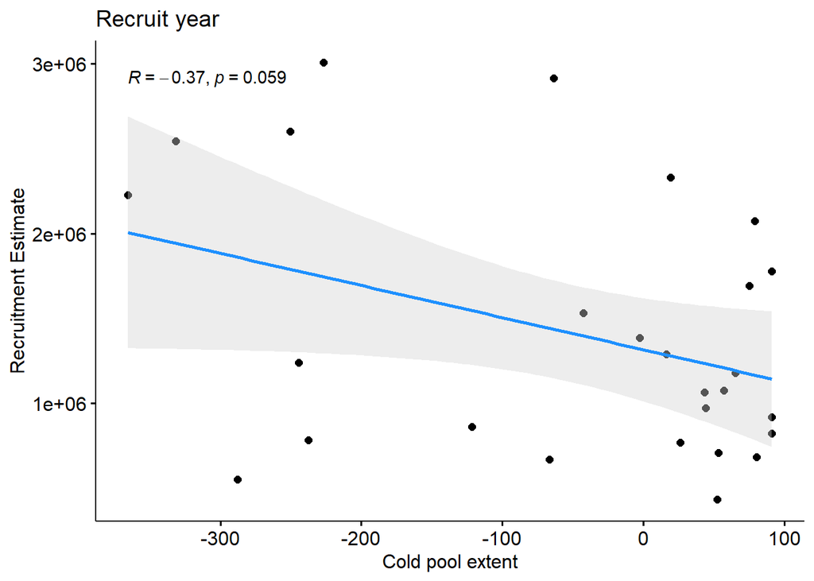

```r
library(ecodata)
# Pull cold pool data
cp.ex <- ecodata::cold_pool
# Selecting just the extent and add 1 year lag
cp <- cp.ex %>% filter(Time %in% c(1994:2020),
              Var == 'extent_index') %>%
  mutate(ext = Value,
         ext_lag1 = lag(ext,1),
         year = as.numeric(Time))


# Join with recruit estimate
cp.rec <- dplyr::full_join(recruit, cp, by = join_by(year)) %>%
  dplyr::select(year, recruit_est, ext, ext_lag1) %>%
  filter(year %in% c(1994:2020))

#no lag
cp.rec %>%
  ggscatter(x = 'ext', y = 'recruit_est',
            add = "reg.line", conf.int = TRUE,
            cor.coef = TRUE, cor.coeff.args = list(method="pearson"),
            add.params=list(color="dodgerblue", fill="lightgray"),
            xlab = "Cold pool extent", ylab = "Recruitment Estimate",
            title="Recruit year")
```

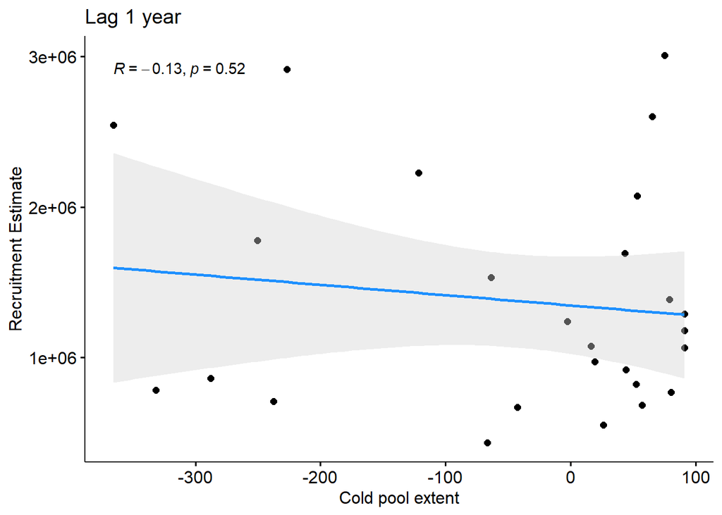

```r
#one year lag
cp.rec %>%
  ggscatter(x = 'ext_lag1', y = 'recruit_est',
            add = "reg.line", conf.int = TRUE,
            cor.coef = TRUE, cor.coeff.args = list(method="pearson"),
            add.params=list(color="dodgerblue", fill="lightgray"),
            xlab = "Cold pool extent", ylab = "Recruitment Estimate",
            title="Lag 1 year")
```

Persistence Index: From tech doc: Model_PI measures the duration of the Cold Pool and is estimated using the month when bottom temperature rises above 10C after the Cold Pool is formed each year

Positive values == Longer Negative values == Shorter

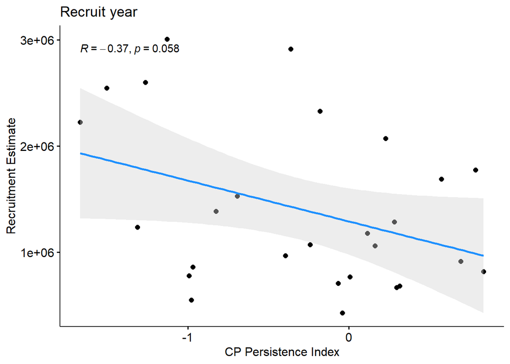

```r
# Selecting just the persitence index
cp.pi <- cp.ex %>% filter(Time %in% c(1994:2020),
              Var == 'persistence_index') %>%
  mutate(pers = Value,
         pers_lag1 = lag(pers,1),
         year = as.numeric(Time))


# Join with recruit estimate
cp.rec <- dplyr::full_join(recruit, cp.pi, by = join_by(year)) %>%
  dplyr::select(year, recruit_est, pers, pers_lag1) %>%
  filter(year %in% c(1994:2020))

#no lag
cp.rec %>%
  ggscatter(x = 'pers', y = 'recruit_est',
            add = "reg.line", conf.int = TRUE,
            cor.coef = TRUE, cor.coeff.args = list(method="pearson"),
            add.params=list(color="dodgerblue", fill="lightgray"),
            xlab = "CP Persistence Index", ylab = "Recruitment Estimate",
            title="Recruit year")
```

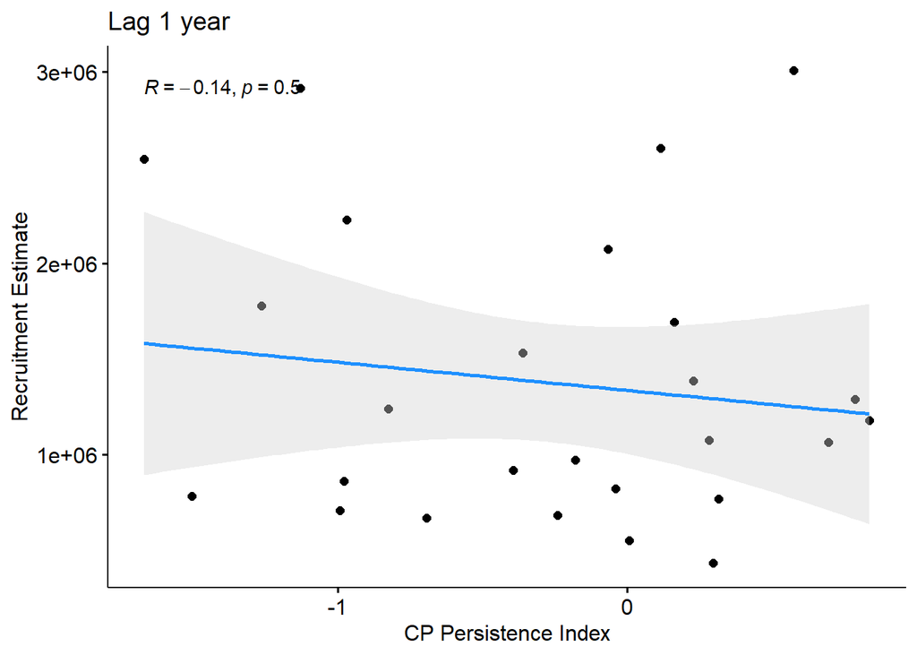

```r
#one year lag
cp.rec %>%
  ggscatter(x = 'pers_lag1', y = 'recruit_est',
            add = "reg.line", conf.int = TRUE,
            cor.coef = TRUE, cor.coeff.args = list(method="pearson"),
            add.params=list(color="dodgerblue", fill="lightgray"),
            xlab = "CP Persistence Index", ylab = "Recruitment Estimate",
            title="Lag 1 year")
```

Cold pool index:

From tech doc: The Model_SEI is estimated by the number of cells where bottom temperature remains below 10C for at least 2 months between June and September.

Positive values == colder Negative values == warmer

Result: Linear positive trend is weak and non-signficant.

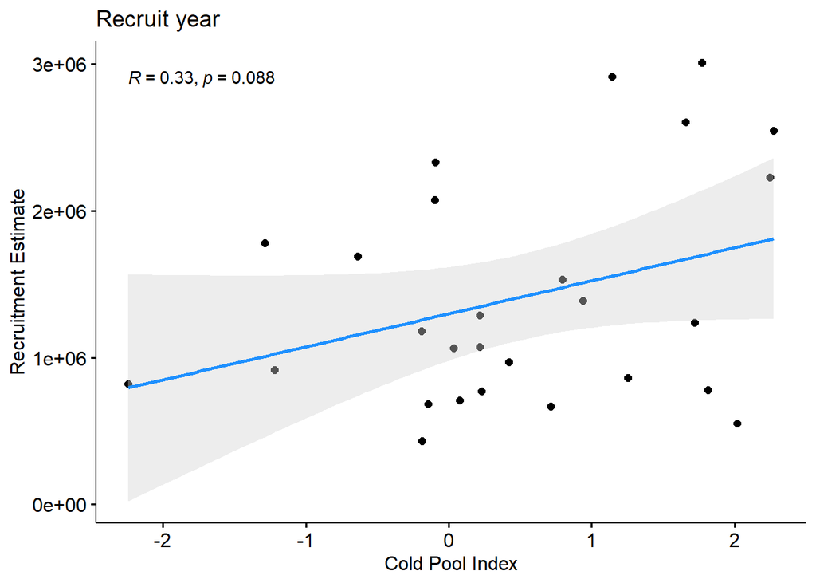

```r
# Selecting just the cp index
cpi <- cp.ex %>% filter(Time %in% c(1994:2020),
              Var == 'cold_pool_index') %>%
  mutate(cpi = Value,
         cpi_lag1 = lag(cpi,1),
         year = as.numeric(Time))


# Join with recruit estimate
cp.rec <- dplyr::full_join(recruit, cpi, by = join_by(year)) %>%
  dplyr::select(year, recruit_est, cpi, cpi_lag1) %>%
  filter(year %in% c(1994:2020))

#no lag
cp.rec %>%
  ggscatter(x = 'cpi', y = 'recruit_est',
            add = "reg.line", conf.int = TRUE,
            cor.coef = TRUE, cor.coeff.args = list(method="pearson"),
            add.params=list(color="dodgerblue", fill="lightgray"),
            xlab = "Cold Pool Index", ylab = "Recruitment Estimate",
            title="Recruit year")
```

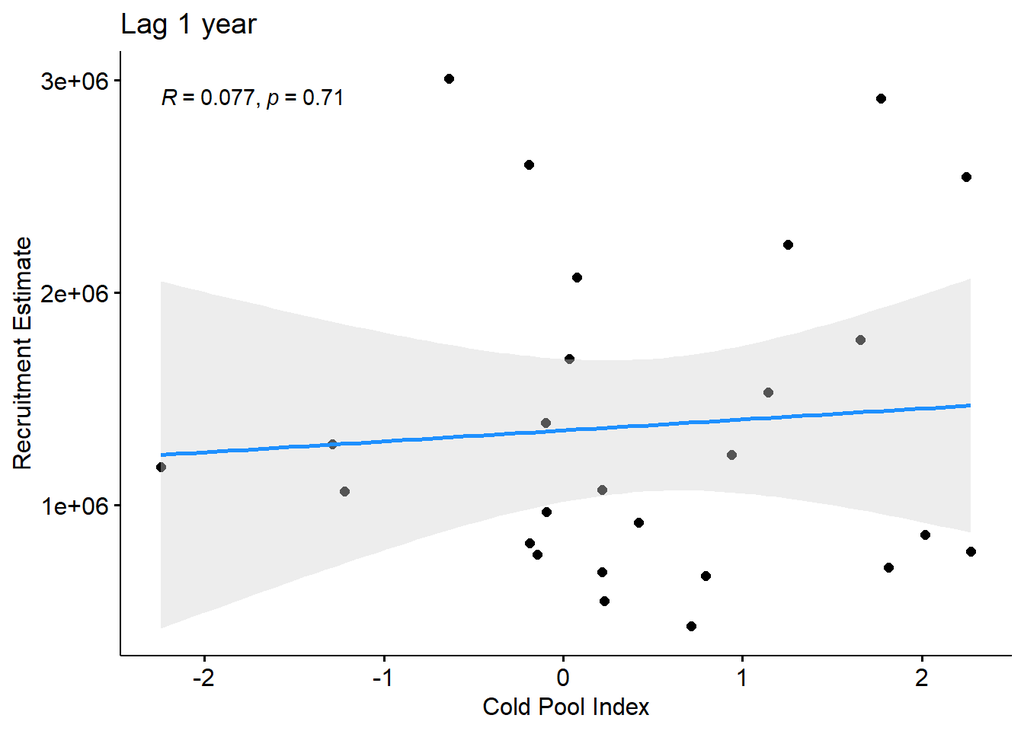

```r
#lag one year
cp.rec %>%
  ggscatter(x = 'cpi_lag1', y = 'recruit_est',
            add = "reg.line", conf.int = TRUE,
            cor.coef = TRUE, cor.coeff.args = list(method="pearson"),
            add.params=list(color="dodgerblue", fill="lightgray"),
            xlab = "Cold Pool Index", ylab = "Recruitment Estimate",
            title="Lag 1 year")
```

##### Shelf water volume

Shelf water volume: A measure of the volume of water bounded inshore of the shelf-slope front. In this analysis, shelf water is defined as all water having salinity <34 psu. The position of the shelf-slope front varies inter-annually with the higher shelf water values indicating the front being pushed further towards the shelf break.

high shv: front pushed towards sbf low shv: front pushed inshore (more slope water on shelf)

Hypothesis: Higher recruitment success correlated with years of higher shelf water volume in spring/summer. These months months may be particularly important as that is when spawning is occurring and the position of the sbf may influence the position of larvae (away from spawning grounds).

Additional variables in this dataset are shelf water temperature and salinity which may also be indicative of habitat conditions.

```r
# Shelf water volume
shlfvol <- read.csv(here::here('data/shelf_water_volume/ShelfWaterVolume_BSB_update.csv'))

# wrangling date info, converting doy to date and month
yrs <- as.vector(nrow(shlfvol))
shlfvol$Year <- as.character(shlfvol$Year)
for (i in 1:nrow(shlfvol)){
  yrs[i] <- strsplit(shlfvol$Year, ".", fixed = TRUE)[[i]][1]
}
shlfvol$year <- yrs

shlfvol <- shlfvol %>% mutate(date_= as.Date(Year.Day-1,
                                             origin=paste0(year, "-01-01")),
                              month= strftime(date_, "%m"),
                              day=strftime(date_,"%d"),
                              year = as.integer(year),
                              month = as.numeric(month))


# Create shw vol by month w/lag
df.lag = shlfvol %>%
  group_by(year,month) %>%
  summarise(mean_t = mean(ShW.T),
            mean_s = mean(ShW.S),
            mean_v = mean(ShW.Vol))
```

##### Shelf Water Volume Analysis

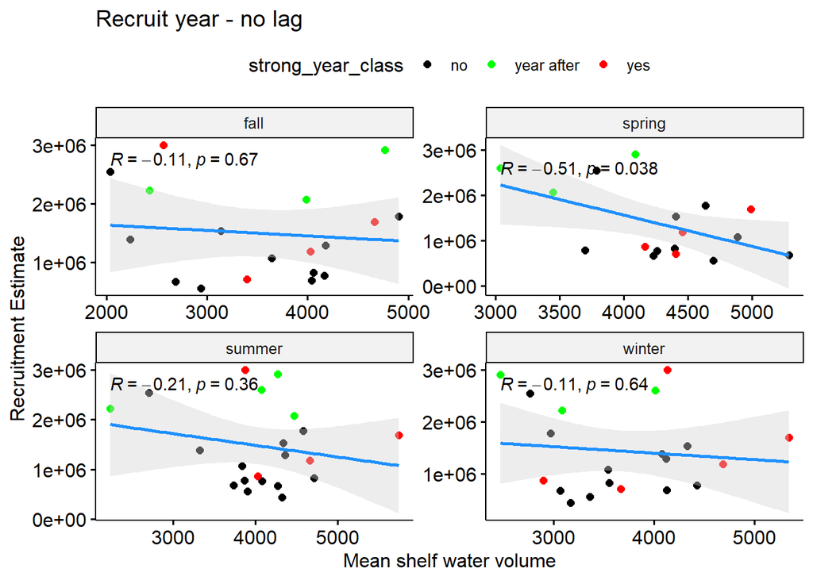

```r
df.join.shlf = dplyr::full_join(recruit, df.lag, by = join_by(year)) %>%
  dplyr::select(year, month, recruit_est, mean_v, mean_t, mean_s) %>%
  tidyr::drop_na() #join with rec dataset

df.join.shlf = df.join.shlf %>%
  filter(year %in% c(1998:2020)) %>%
  mutate(
         v_lag12 = lag(mean_v,12),
         t_lag12 = lag(mean_t,12),
         s_lag12 = lag(mean_s,12)) #creating one year lags

df = df.join.shlf %>%
  mutate(season = case_when(month %in% c(1,2,3) ~ 'winter',
                            month %in% c(4,5,6) ~ 'spring',
                            month %in% c(7,8,9) ~ 'summer',
                            month %in% c(10,11,12) ~ 'fall'),
         strong_year_class = case_when(year %in% c(1998,1999,2005,2013,2017) ~ 'yes',
                                  year %in% c(2000,2006,2014,2018) ~ 'year after',
                                  year %in% c(2001:2004,2007:2012,2015:2016,2019:2020) ~ 'no'))


# Plot without lag
df %>% group_by(year, season, strong_year_class) %>%
  summarize(v = mean(mean_v),
            r = mean(recruit_est)) %>%
  ggscatter(x = "v", y = "r",
            add = "reg.line", conf.int = TRUE,
            color = "strong_year_class", palette = c("black", "green", "red"),
            cor.coef = TRUE, cor.coeff.args = list(method="pearson"),
            add.params=list(color="dodgerblue", fill="lightgray"),
            xlab = "Mean shelf water volume", ylab = "Recruitment Estimate",
            title="Recruit year - no lag")+
  facet_wrap(~season, scales = 'free')
```

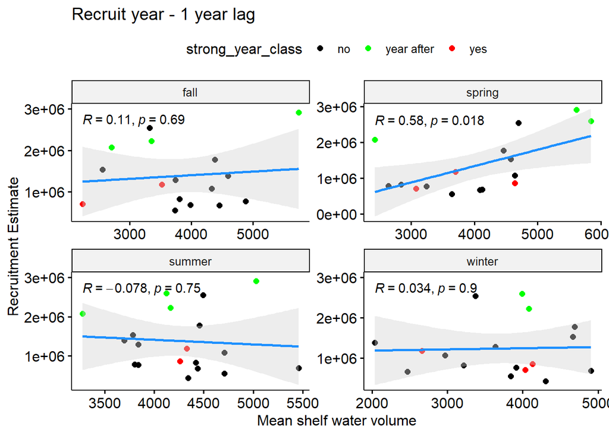

```r
# Plot with lag
df %>% group_by(year, season, strong_year_class) %>%
  summarize(v = mean(v_lag12),
            r = mean(recruit_est)) %>%
  ggscatter(x = "v", y = "r",
            add = "reg.line", conf.int = TRUE,
            color = "strong_year_class", palette = c("black", "green", "red"),
            cor.coef = TRUE, cor.coeff.args = list(method="pearson"),
            add.params=list(color="dodgerblue", fill="lightgray"),
            xlab = "Mean shelf water volume", ylab = "Recruitment Estimate",
            title="Recruit year - 1 year lag")+
  facet_wrap(~season, scales = 'free')
```

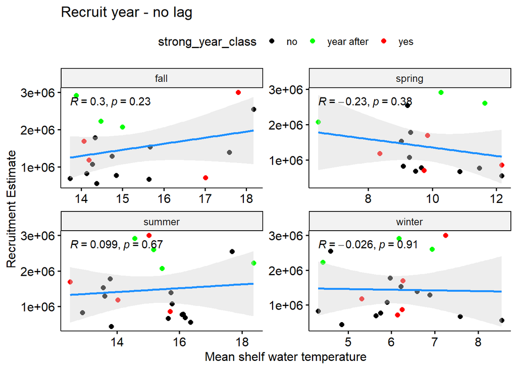

```r
#######################################################

##shelf water temperature

#no lag
df %>% group_by(year, season, strong_year_class) %>%
  summarize(v = mean(mean_t),
            r = mean(recruit_est)) %>%
  ggscatter(x = "v", y = "r",
            add = "reg.line", conf.int = TRUE,
            color = "strong_year_class", palette = c("black", "green", "red"),
            cor.coef = TRUE, cor.coeff.args = list(method="pearson"),
            add.params=list(color="dodgerblue", fill="lightgray"),
            xlab = "Mean shelf water temperature", ylab = "Recruitment Estimate",
            title="Recruit year - no lag")+
  facet_wrap(~season, scales = 'free')
```

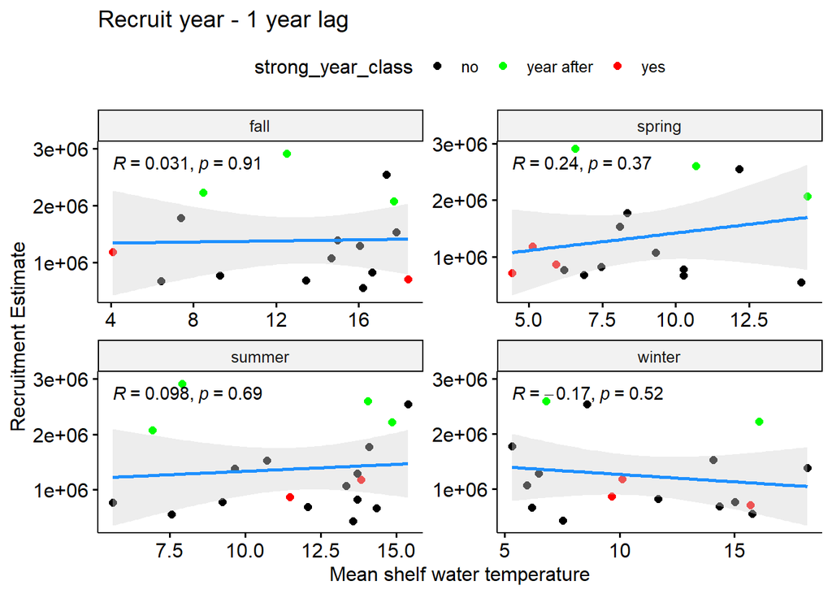

```r
# Plot with lag
df %>% group_by(year, season, strong_year_class) %>%
  summarize(v = mean(t_lag12),
            r = mean(recruit_est)) %>%
  ggscatter(x = "v", y = "r",
            add = "reg.line", conf.int = TRUE,
            color = "strong_year_class", palette = c("black", "green", "red"),
            cor.coef = TRUE, cor.coeff.args = list(method="pearson"),
            add.params=list(color="dodgerblue", fill="lightgray"),
            xlab = "Mean shelf water temperature", ylab = "Recruitment Estimate",
            title="Recruit year - 1 year lag")+
  facet_wrap(~season, scales = 'free')
```

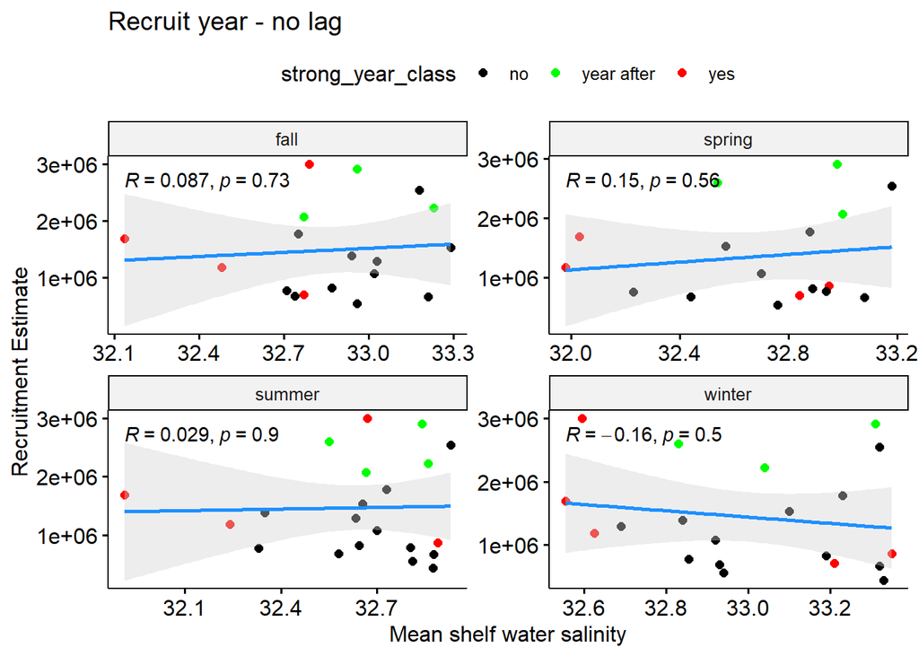

```r
####################################################

##shelf water salinity

#no lag
df %>% group_by(year, season, strong_year_class) %>%
  summarize(v = mean(mean_s),
            r = mean(recruit_est)) %>%
  ggscatter(x = "v", y = "r",
            add = "reg.line", conf.int = TRUE,
            color = "strong_year_class", palette = c("black", "green", "red"),
            cor.coef = TRUE, cor.coeff.args = list(method="pearson"),
            add.params=list(color="dodgerblue", fill="lightgray"),
            xlab = "Mean shelf water salinity", ylab = "Recruitment Estimate",
            title="Recruit year - no lag")+
  facet_wrap(~season, scales = 'free')
```

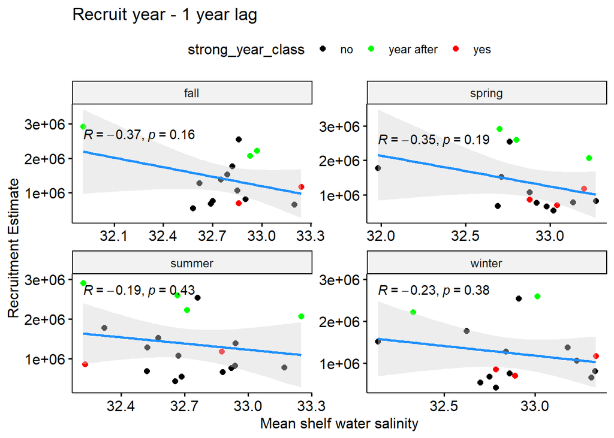

```r
# Plot with lag
df %>% group_by(year, season, strong_year_class) %>%
  summarize(v = mean(s_lag12),
            r = mean(recruit_est)) %>%
  ggscatter(x = "v", y = "r",
            add = "reg.line", conf.int = TRUE,
            color = "strong_year_class", palette = c("black", "green", "red"),
            cor.coef = TRUE, cor.coeff.args = list(method="pearson"),
            add.params=list(color="dodgerblue", fill="lightgray"),
            xlab = "Mean shelf water salinity", ylab = "Recruitment Estimate",
            title="Recruit year - 1 year lag")+
  facet_wrap(~season, scales = 'free')
```

##### Gulf-stream index

Gulf stream index was calculated based on method presented by Pérez-Hernández and Joyce (2014). The gulf stream index (GSI) is a measure of the degrees latitude above the average Gulf Stream position based on ocean temperature at 200m (15 C) depth between 55W to 75W.

Positive values indicate a the mean position of the GS is more Northernly, whereas negative values indicate a more Southernly position.

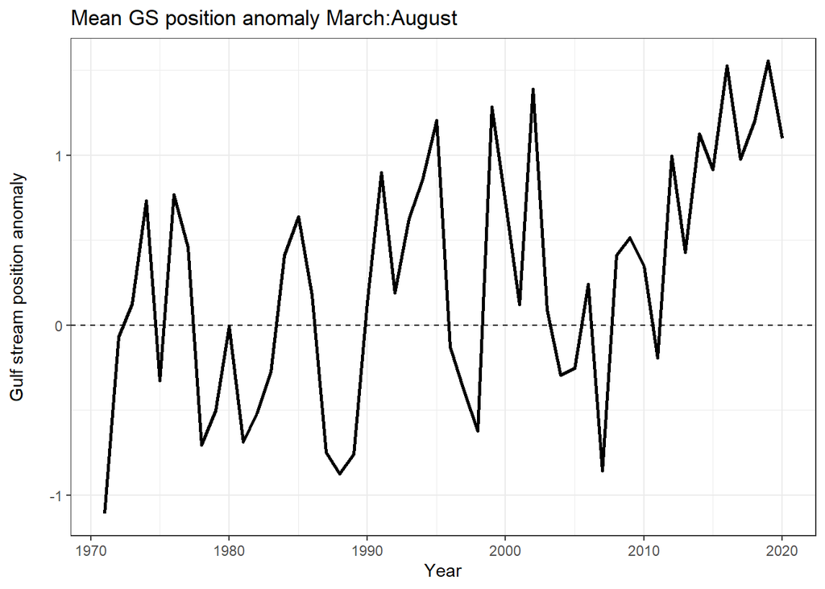

```r
gsi.m <- read.csv(here::here('data/gulf_stream_index/mm_gsi_1954_2022_chen.csv'))


## --- This joins recruit estimate data to GSI data and
## --- calculates some summary stats(mean, sd, min, max)
df <- dplyr::full_join(recruit, gsi.m %>%
                   group_by(year) %>%
                   filter(month %in% c(3:8)) %>%
                   summarise(m.gsi = mean(GSI),
                             sd.gsi = sd(GSI),
                             max.gsi = max(GSI),
                             min.gsi = min(GSI)),
                 by = join_by(year)) %>%
  mutate(pos = ifelse(m.gsi > 0, 'Northerly', 'Southerly'),
         n.pos = ifelse(m.gsi > 0, 1, 0))
df <- df[-c(51:69),] # this removes rows w/years that don't match
# (could/should do this before hand in more standardized way - will do later)

# Plot the time series (mean GSI for the months of interest)
# -- Note: here I am looking just at March through August assuming these
# months are the most important to recently spawned individuals
ggplot(data = df,
       aes(x = year, y = m.gsi)) +
  geom_line(lwd = 1) +
  geom_hline(yintercept = 0, lty = 2) +
  labs(title = 'Mean GS position anomaly March:August',
       x = 'Year',
       y = "Gulf stream position anomaly\n") +
theme_bw()
```

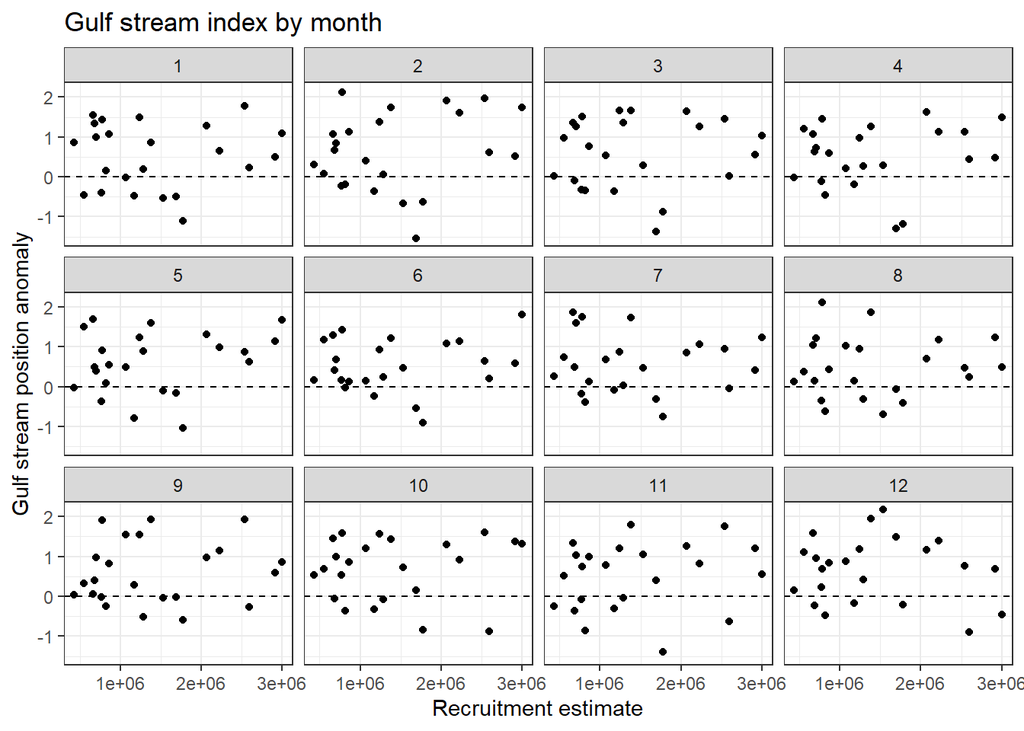

```r
# Looking across all months
dplyr::full_join(recruit, gsi.m, by = join_by(year)) %>%
  dplyr::select(year, month, recruit_est, GSI) %>%
  #filter(month %in% c(3:9)) %>%
  filter(year>1997) %>%
  tidyr::drop_na() %>%
ggplot2::ggplot(.,aes(x=recruit_est, y=GSI)) +
  geom_point(color = 'black') +
  facet_wrap(~month)+
  xlab('Recruitment estimate') +
  ylab('Gulf stream position anomaly') +
  labs(title = 'Gulf stream index by month') +
  geom_hline(yintercept = 0, lty = 2) +
  theme_bw()
```

##### Gulf Stream Index Analysis

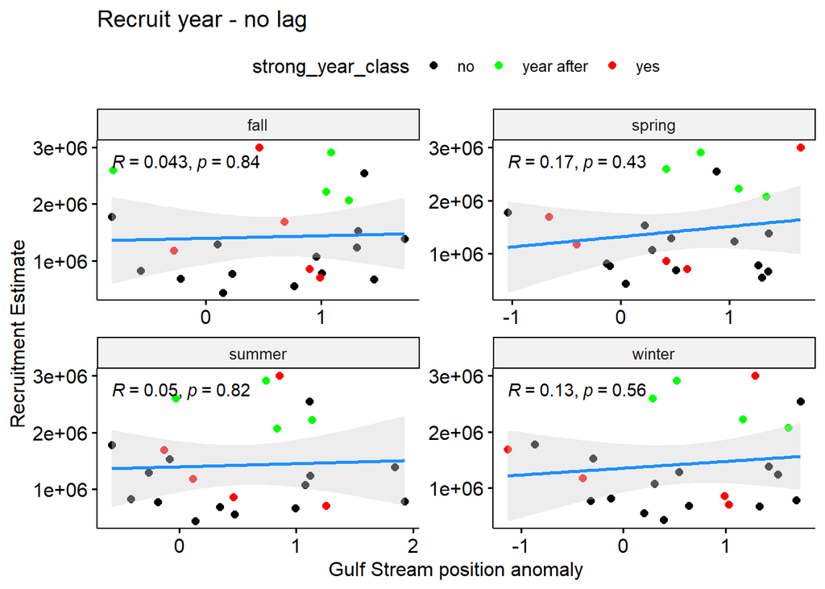

```r
df.gsi = dplyr::full_join(recruit, gsi.m, by = join_by(year)) %>%
  dplyr::select(year, month, recruit_est, GSI) %>%
  mutate(
        gsi_12 = lag(GSI,12)) %>%
  filter(year>1997) %>%
  tidyr::drop_na() #GSI by month and with year lag

df = df.gsi %>%
  mutate(season = case_when(month %in% c(1,2,3) ~ 'winter',
                            month %in% c(4,5,6) ~ 'spring',
                            month %in% c(7,8,9) ~ 'summer',
                            month %in% c(10,11,12) ~ 'fall'),
         strong_year_class = case_when(year %in% c(1998,1999,2005,2013,2017) ~ 'yes',
                                  year %in% c(2000,2006,2014,2018) ~ 'year after',
                                  year %in% c(2001:2004,2007:2012,2015:2016,2019:2020) ~ 'no'))

# Plot without lag
df %>% group_by(year, season, strong_year_class) %>%
  summarize(gsi = mean(GSI),
            r = mean(recruit_est)) %>%
  ggscatter(x = "gsi", y = "r",
            add = "reg.line", conf.int = TRUE,
            color = "strong_year_class", palette = c("black", "green", "red"),
            cor.coef = TRUE, cor.coeff.args = list(method="pearson"),
            add.params=list(color="dodgerblue", fill="lightgray"),
            xlab = "Gulf Stream position anomaly", ylab = "Recruitment Estimate",
            title="Recruit year - no lag")+
  facet_wrap(~season, scales = 'free')
```

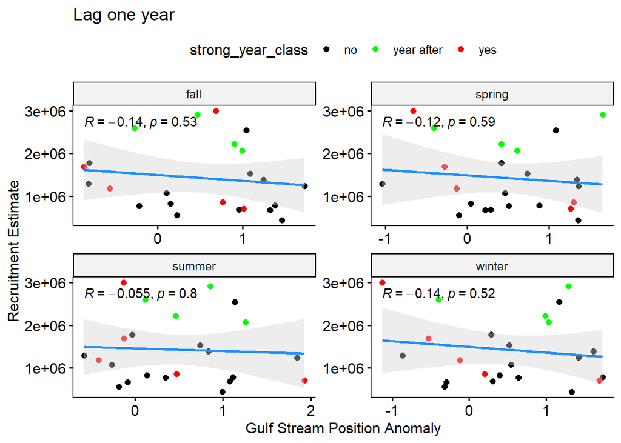

```r
# Plot with 1 year lag
df %>% group_by(year, season, strong_year_class) %>%
  summarize(gsi = mean(gsi_12),
            r = mean(recruit_est)) %>%
  ggscatter(x = "gsi", y = "r",
            add = "reg.line", conf.int = TRUE,
            color = "strong_year_class", palette = c("black", "green", "red"),
            cor.coef = TRUE, cor.coeff.args = list(method="pearson"),
            add.params=list(color="dodgerblue", fill="lightgray"),
            xlab = "Gulf Stream Position Anomaly", ylab = "Recruitment Estimate",
            title="Lag one year")+
  facet_wrap(~season, scales = 'free')
```

#### Food availablity

Larval tilefish eat zooplankton, likely calanus. *Calanus finmarchicus* are a copepod (crustacean) with a one-year life cycle and are an important food source for many commercially important species. Calanus spp. are lipid rich, herbivorous species that eat phytoplankton, diatoms in particular (Hobbs et al. 2020).

Diatoms are often represented as microplankton (>20 µm), but many species are of the nanoplankton size class (2-20 µm), and a smaller few may even overlap with picoplanton size class (<2 µm).

##### Microplankton

```r
micro<-read.csv(here::here('data/phyto_size_class/microplankton_ts_gtf_strata.csv'))

# micro with year lag
micro.lag <- micro %>%
  arrange(year, month) %>%
  mutate(
         micro_12 = lag(weighted_mean_micro,12))

# Join with recruit estimate
micro.rec <- dplyr::full_join(recruit, micro.lag %>%
                   group_by(year) %>%
                   filter(year %in% c(1998:2020)),
dplyr::select(year, month, mean_cpue, mean_micro, weighted_mean_micro, micro_12),
                 by = join_by(year))
micro.rec <- micro.rec[-c(1:27),] #removes year < 1998 (starting year for analysis)
```

##### Microplankton analysis

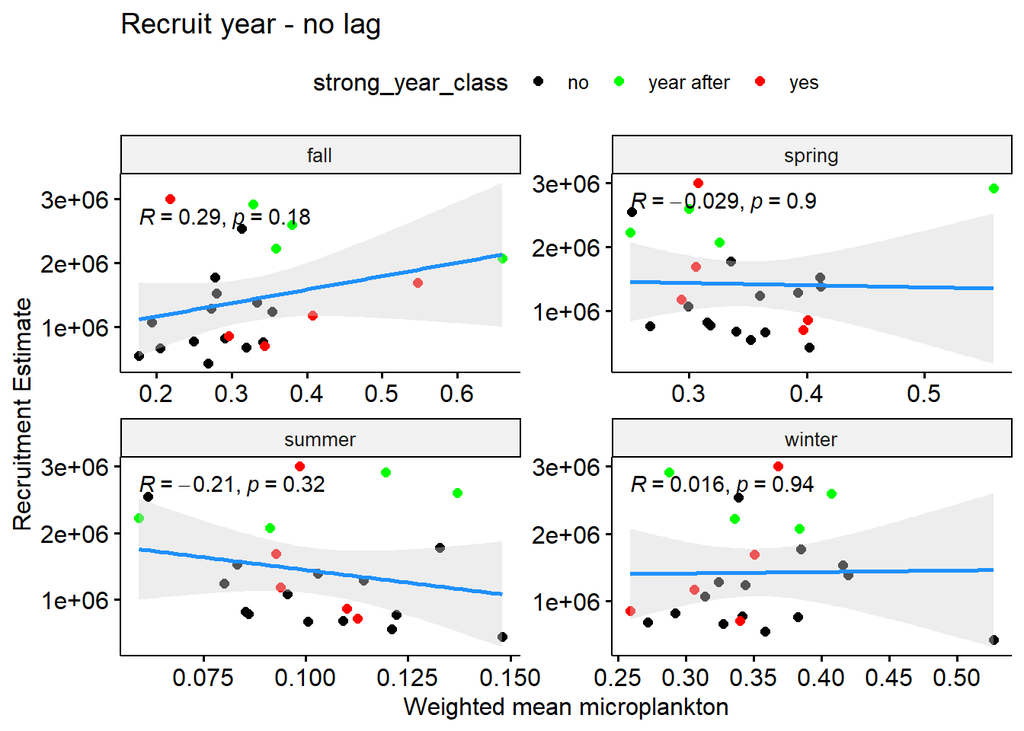

```r
df = micro.rec %>%
  mutate(season = case_when(month %in% c(1,2,3) ~ 'winter',
                            month %in% c(4,5,6) ~ 'spring',
                            month %in% c(7,8,9) ~ 'summer',
                            month %in% c(10,11,12) ~ 'fall'),
         strong_year_class = case_when(year %in% c(1998,1999,2005,2013,2017) ~ 'yes',
                                  year %in% c(2000,2006,2014,2018) ~ 'year after',
                                  year %in% c(2001:2004,2007:2012,2015:2016,2019:2020) ~ 'no'))

# Plot without lag
df %>% group_by(year, season, strong_year_class) %>%
  summarize(micro = mean(weighted_mean_micro),
            r = mean(recruit_est)) %>%
  ggscatter(x = "micro", y = "r",
            add = "reg.line", conf.int = TRUE,
            color = "strong_year_class", palette = c("black", "green", "red"),
            cor.coef = TRUE, cor.coeff.args = list(method="pearson"),
            add.params=list(color="dodgerblue", fill="lightgray"),
            xlab = "Weighted mean microplankton", ylab = "Recruitment Estimate",
            title="Recruit year - no lag")+
  facet_wrap(~season, scales = 'free')
```

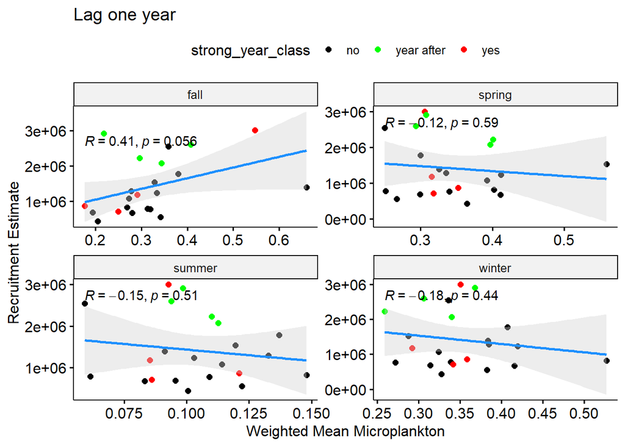

```r
# Plot with lag
df %>% group_by(year, season, strong_year_class) %>%
  summarize(micro = mean(micro_12),
            r = mean(recruit_est)) %>%
  ggscatter(x = "micro", y = "r",
            add = "reg.line", conf.int = TRUE,
            color = "strong_year_class", palette = c("black", "green", "red"),
            cor.coef = TRUE, cor.coeff.args = list(method="pearson"),
            add.params=list(color="dodgerblue", fill="lightgray"),
            xlab = "Weighted Mean Microplankton", ylab = "Recruitment Estimate",
            title="Lag one year")+
  facet_wrap(~season, scales = 'free')
```

##### Chlorophyll-A

```r
# CHL-A
chl<-read.csv(here::here('data/chl/chl_ts_gtf_strata.csv'))

# chl with year lag
chl.lag <- chl %>%
  arrange(year, month) %>%
  mutate(
         chl_12 = lag(weighted_mean_chl,12))

# Join with recruit estimate
chl.rec <- dplyr::full_join(recruit, chl.lag %>%
                   group_by(year) %>%
                   filter(year %in% c(1998:2020)),
dplyr::select(year, month, mean_cpue, mean_chl, weighted_mean_chl,chl_12),
                 by = join_by(year))
chl.rec <- chl.rec[-c(1:27),] #removes year < 1998 (starting year for analysis)
```

##### Chlorophyll-A analysis

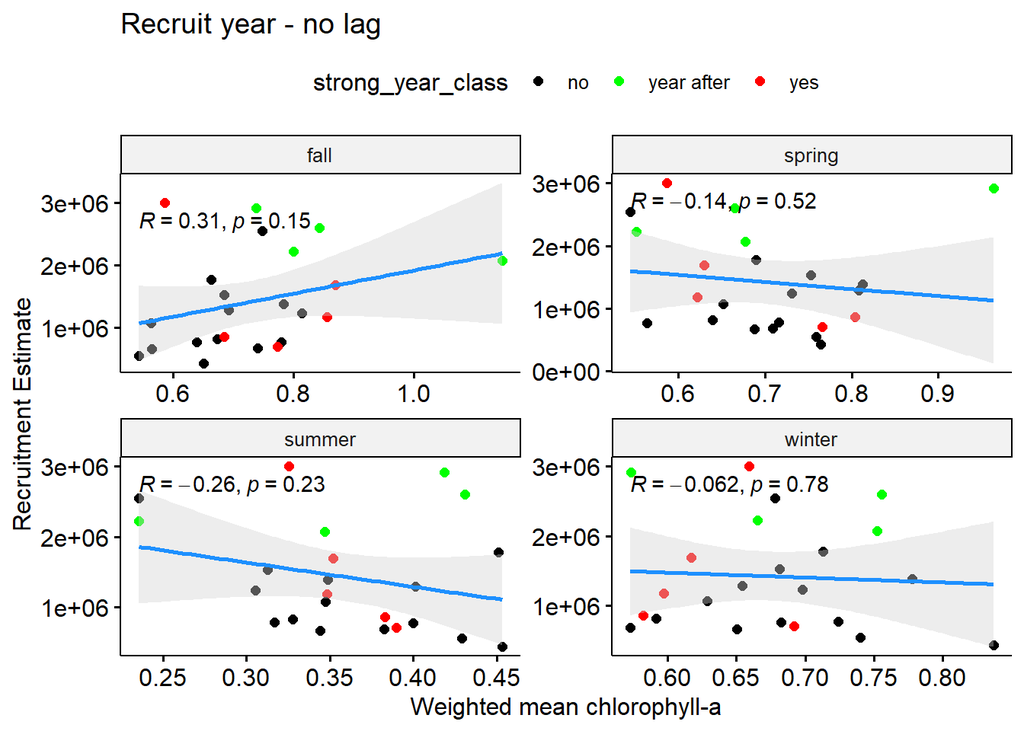

```r
df = chl.rec %>%
  mutate(season = case_when(month %in% c(1,2,3) ~ 'winter',
                            month %in% c(4,5,6) ~ 'spring',
                            month %in% c(7,8,9) ~ 'summer',
                            month %in% c(10,11,12) ~ 'fall'),
         strong_year_class = case_when(year %in% c(1998,1999,2005,2013,2017) ~ 'yes',
                                  year %in% c(2000,2006,2014,2018) ~ 'year after',
                                  year %in% c(2001:2004,2007:2012,2015:2016,2019:2020) ~ 'no'))

# Plot without lag
df %>% group_by(year, season, strong_year_class) %>%
  summarize(chl = mean(weighted_mean_chl),
            r = mean(recruit_est)) %>%
  ggscatter(x = "chl", y = "r",
            add = "reg.line", conf.int = TRUE,
             color = "strong_year_class", palette = c("black", "green", "red"),
            cor.coef = TRUE, cor.coeff.args = list(method="pearson"),
            add.params=list(color="dodgerblue", fill="lightgray"),
            xlab = "Weighted mean chlorophyll-a", ylab = "Recruitment Estimate",
            title="Recruit year - no lag")+
  facet_wrap(~season, scales = 'free')
```

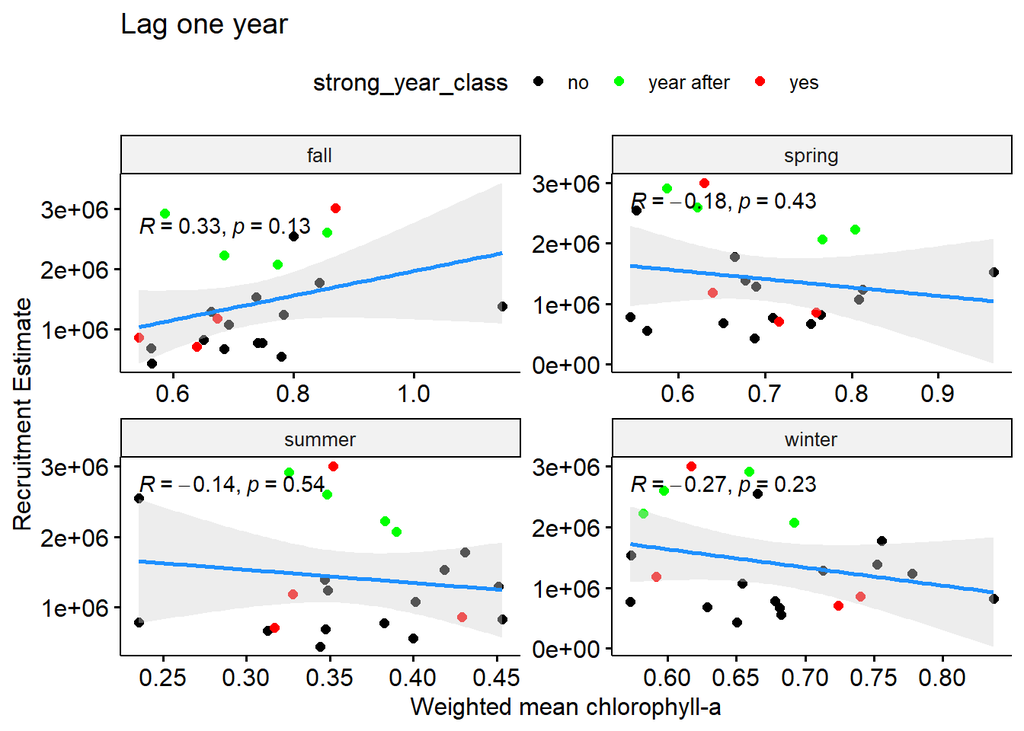

```r
# Plot with lag
df %>% group_by(year, season, strong_year_class) %>%
  summarize(chl = mean(chl_12),
            r = mean(recruit_est)) %>%
  ggscatter(x = "chl", y = "r",
            add = "reg.line", conf.int = TRUE,
             color = "strong_year_class", palette = c("black", "green", "red"),
            cor.coef = TRUE, cor.coeff.args = list(method="pearson"),
            add.params=list(color="dodgerblue", fill="lightgray"),
            xlab = "Weighted mean chlorophyll-a", ylab = "Recruitment Estimate",
            title="Lag one year")+
  facet_wrap(~season, scales = 'free')
```

References:

Joyce, Terrence M, Young-Oh Kwon, Hyodae Seo, and Caroline C Ummenhofer. 2019. “Meridional Gulf Stream Shifts Can Influence Wintertime Variability in the North Atlantic Storm Track and Greenland Blocking.” Geophysical Research Letters 46 (3): 1702–8. https://doi.org/10.1029/2018GL081087.

Hobbs, L., Banas, N. S., Cottier, F. R., Berge, J., & Daase, M. (2020). Eat or sleep: availability of winter prey explains mid-winter and spring activity in an Arctic Calanus population. Frontiers in Marine Science, 7, 541564.

Pérez-Hernández, M. Dolores, and Terrence M. Joyce. 2014. “Two Modes of Gulf Stream Variability Revealed in the Last Two Decades of Satellite Altimeter Data.” Journal of Physical Oceanography 44 (1): 149–63. https://doi.org/10.1175/JPO-D-13-0136.1.